# Reproduciblity: Bayesian Regression for Directional Data

# Loading the R Package

```r
library(RBVNF)
load_packages()
```

```
##
## Rfast: 2.1.0
```

[output not shown]

```r
load_additional_packages()
```

## Simulated Data Generation and EM for Posterior Mode (d=2, Circular Data):

In this part of the demonstration, we generate a dataset of size n=750, with p=10 (10 covariates) and the responses are circular,i.e., d=2. Then we fit the EM algorithm to estimate the regression coefficients. True value of the regression coefficients, and its estimates are printed.

```r
n=750  # NUmber of the samples
p=10    # NUmber of the regression covariates
d=2     # Number of direcions in the direcional data
#### bbeta is a matrix of dimension p\times d
#bbeta=matrix( rnorm(p*d), nrow=p, ncol=d)
sigma_square=1
tau_square=10000
data_lst = Data_generator_vnf_reg(n=n, p=p, d=d, concentration_factor = 1, beta_factor = 10)
Y = data_lst$Y;X=data_lst$X;

# Fitting the EM algorithm for the Standard Regresion for directional responses: This takes less than a minute.
beta_EM=EM_Dir_regression_optimizer_V1(Y=Y, X=X, prior=NULL, beta_init = NULL,   EM_tolerence = .00001)
```

```
## [1] 2
## [1] 3
## [1] 4
## [1] 5
## [1] 6
## [1] 7
## [1] 8
## [1] 9
## [1] 10
## [1] 11
## [1] 12
## [1] 13
## [1] 14
## [1] 15
## [1] 16
```

[output cut: 352 more lines]

```r
print(beta_EM)
```

```
##              Y_1       Y_2
##  [1,] -5.6534288  1.760947
##  [2,]  7.6767128  6.094513
##  [3,]  6.9242952 -6.356717
##  [4,] -6.8880941 -6.480081
##  [5,] -1.5345845 -1.570287
##  [6,] -5.9916621 -6.228898
##  [7,] -5.9651777  2.692121
##  [8,] -0.4389931 -4.361106
##  [9,] -3.1038256  3.984973
## [10,]  0.4944639 -8.291118
```

```r
print(cbind(EstimatedValue=c(t(beta_EM)),TrueValue=c(t(data_lst$beta))))
```

```
##       EstimatedValue  TrueValue
##  [1,]     -5.6534288 -5.8416578
##  [2,]      1.7609469  1.9544458
##  [3,]      7.6767128  7.4000719
##  [4,]      6.0945129  5.9802931
##  [5,]      6.9242952  6.8798618
##  [6,]     -6.3567166 -6.9046173
##  [7,]     -6.8880941 -7.0528680
##  [8,]     -6.4800811 -6.9984199
##  [9,]     -1.5345845 -1.7519233
## [10,]     -1.5702871 -1.5022602
## [11,]     -5.9916621 -6.1839883
## [12,]     -6.2288980 -6.7599578
## [13,]     -5.9651777 -6.0861591
## [14,]      2.6921214  2.9413596
## [15,]     -0.4389931 -0.2869763
## [16,]     -4.3611058 -4.3621643
## [17,]     -3.1038256 -3.3662065
## [18,]      3.9849726  4.3853534
## [19,]      0.4944639  0.4453659
## [20,]     -8.2911184 -8.6610674
```

## Bayesian MCMC Algorithm (d=2):

Here we obtain the posterior samples of the regression coefficients using the MCMC algorithm.

```r
# Change Sample Size to get the full MCMC. MCMC step takes time depending on the sample size. This step can take 20 to 30 minutes. Prints output after every 100 samples are generated.
lst=MCMC_Dir_regression_sampler_V1(Y=data_lst$Y, X=data_lst$X, prior=NULL, beta_init = NULL, MCSamplerSize =100)
```

```
## [1] "Default Procedure using EM is being used to obtain initial value of the regression coefficients that will be  used to start the MCMC Data Augmentation Algorithm. Iteration number of EM algorithm is being printed untill convergence."
## [1] 2
## [1] 3
## [1] 4
## [1] 5
## [1] 6
## [1] 7
## [1] 8
## [1] 9
## [1] 10
## [1] 11
## [1] 12
## [1] 13
## [1] 14
## [1] 15
```

[output cut: 355 more lines]

The triplet plot (autocorrelation, traceplot and density plot) for some of the regression coefficient is plotted (d=2)

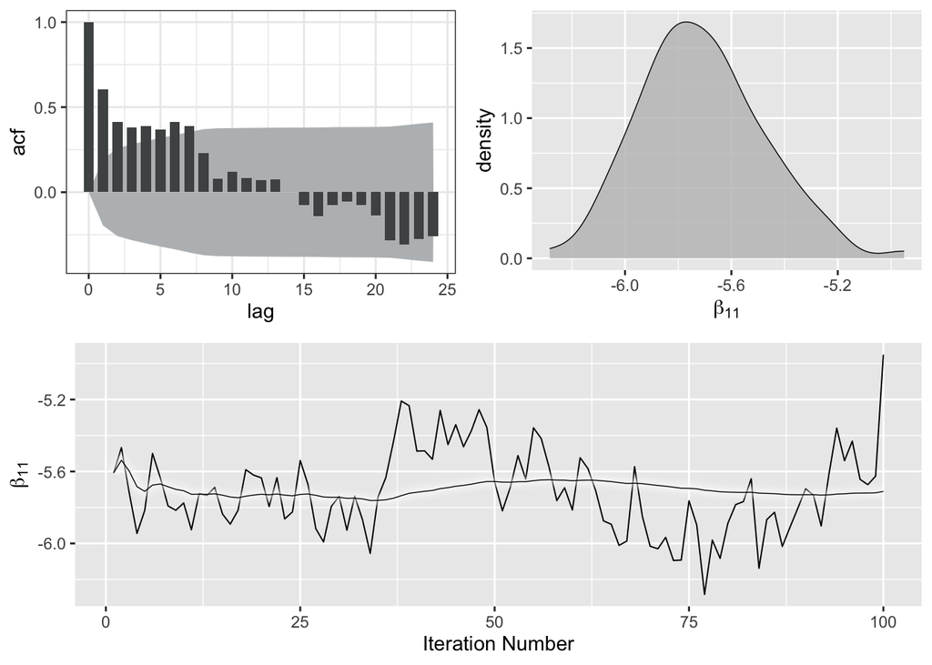

```r
# Summary from MCMC output
i=1;j= 1
  Plot_MCMC_Diag_Triplet(lst$MC$Mc_Beta[,i,j],y_lab_text = bquote(beta[.(i)][.(j)]))
```

```r
  Posterior_mean=apply(lst$MC$Mc_Beta, MARGIN = c(2,3), FUN = mean)
  Posterior_SD=apply(lst$MC$Mc_Beta, MARGIN = c(2,3), FUN = sd)
  print(cbind(Posterior_mean=c(t(Posterior_mean)),TrueValue=c(t(data_lst$beta))))
```

```
##       Posterior_mean  TrueValue
##  [1,]     -5.7109957 -5.8416578
##  [2,]      1.6923535  1.9544458
##  [3,]      7.7337313  7.4000719
##  [4,]      6.1001688  5.9802931
##  [5,]      6.9419851  6.8798618
##  [6,]     -6.4139331 -6.9046173
##  [7,]     -6.9477618 -7.0528680
##  [8,]     -6.4985278 -6.9984199
##  [9,]     -1.5502010 -1.7519233
## [10,]     -1.6006736 -1.5022602
## [11,]     -6.0370841 -6.1839883
## [12,]     -6.3114836 -6.7599578
## [13,]     -6.0669120 -6.0861591
## [14,]      2.6872175  2.9413596
## [15,]     -0.4682559 -0.2869763
## [16,]     -4.3394824 -4.3621643
## [17,]     -3.2050548 -3.3662065
## [18,]      4.0233414  4.3853534
## [19,]      0.4460007  0.4453659
## [20,]     -8.3563259 -8.6610674
```

## Simulated Data Generation and EM for Posterior Mode (d=3, Spherical Data):

```r
n=750  # NUmber of the samples
p=10    # NUmber of the regression covariates
d=3     # Number of direcions in the direcional data
#### bbeta is a matrix of dimension p\times d
#bbeta=matrix( rnorm(p*d), nrow=p, ncol=d)
sigma_square=1
tau_square=10000
data_lst = Data_generator_vnf_reg(n=n, p=p, d=d, concentration_factor = 1, beta_factor = 10)
Y = data_lst$Y;X=data_lst$X;

# Fitting the EM algorithm for the Standard Regresion for directional responses: This takes less than a minute.
beta_EM=EM_Dir_regression_optimizer_V1(Y=Y, X=X, prior=NULL, beta_init = NULL,   EM_tolerence = .00001)
```

```
## [1] 2
## [1] 3
## [1] 4
## [1] 5
## [1] 6
## [1] 7
## [1] 8
## [1] 9
## [1] 10
## [1] 11
## [1] 12
## [1] 13
## [1] 14
## [1] 15
## [1] 16
```

[output cut: 273 more lines]

```r
print(beta_EM)
```

```
##              Y_1       Y_2       Y_3
##  [1,] -5.3775298 -9.560598 -5.906484
##  [2,]  5.9042165 -3.885162 -5.752809
##  [3,] -2.7552380  5.357687  9.648035
##  [4,]  9.3258890  4.995013 -9.216307
##  [5,]  2.5686816 -4.524527 -8.029596
##  [6,]  0.3392928 -1.617618  3.105171
##  [7,] -1.6783974  4.221376 -5.020839
##  [8,]  9.4823442  4.785226  8.309548
##  [9,] -4.1627430 -6.259370 -5.341039
## [10,]  2.0036647 -4.786689  2.286737
```

```r
print(cbind(EstimatedValue=c(t(beta_EM)),TrueValue=c(t(data_lst$beta))))
```

```
##       EstimatedValue  TrueValue
##  [1,]     -5.3775298 -5.4105569
##  [2,]     -9.5605982 -9.3894022
##  [3,]     -5.9064841 -5.4660828
##  [4,]      5.9042165  5.6187613
##  [5,]     -3.8851618 -4.0107448
##  [6,]     -5.7528092 -5.7964092
##  [7,]     -2.7552380 -2.8890628
##  [8,]      5.3576871  5.3134239
##  [9,]      9.6480355  9.4712037
## [10,]      9.3258890  8.6712123
## [11,]      4.9950128  5.2527169
## [12,]     -9.2163069 -8.5468151
## [13,]      2.5686816  2.3435710
## [14,]     -4.5245273 -4.8440620
```

[output cut: 16 more lines]

## Bayesian MCMC Algorithm(d=3):

Here we obtain the posterior samples of the regression coefficients using the MCMC algorithm.

```r
# Change Sample Size to get the full MCMC. MCMC step takes time depending on the sample size. This step can take 20 to 30 minutes. Prints output after every 100 samples are generated.
lst=MCMC_Dir_regression_sampler_V1(Y=data_lst$Y, X=data_lst$X, prior=NULL, beta_init = NULL, MCSamplerSize =100)
```

```
## [1] "Default Procedure using EM is being used to obtain initial value of the regression coefficients that will be  used to start the MCMC Data Augmentation Algorithm. Iteration number of EM algorithm is being printed untill convergence."
## [1] 2
## [1] 3
## [1] 4
## [1] 5
## [1] 6
## [1] 7
## [1] 8
## [1] 9
## [1] 10
## [1] 11
## [1] 12
## [1] 13
## [1] 14
## [1] 15
```

[output cut: 276 more lines]

The triplet plot (autocorrelation, traceplot and density plot) for some of the regression coefficient is plotted (d=3)

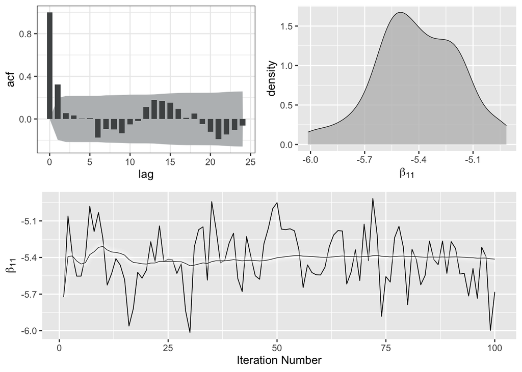

```r
# Summary from MCMC output
i=1;j= 1
  Plot_MCMC_Diag_Triplet(lst$MC$Mc_Beta[,i,j],y_lab_text = bquote(beta[.(i)][.(j)]))
```

```r
  Posterior_mean=apply(lst$MC$Mc_Beta, MARGIN = c(2,3), FUN = mean)
  Posterior_SD=apply( lst$MC$Mc_Beta, MARGIN = c(2,3), FUN = sd)
  print(cbind(Posterior_mean=c(t(Posterior_mean)),TrueValue=c(t(data_lst$beta))))
```

```
##       Posterior_mean  TrueValue
##  [1,]     -5.4131828 -5.4105569
##  [2,]     -9.6473921 -9.3894022
##  [3,]     -5.9969415 -5.4660828
##  [4,]      5.9143731  5.6187613
##  [5,]     -3.9435286 -4.0107448
##  [6,]     -5.8147328 -5.7964092
##  [7,]     -2.7429362 -2.8890628
##  [8,]      5.4009979  5.3134239
##  [9,]      9.6974898  9.4712037
## [10,]      9.4180601  8.6712123
## [11,]      5.0774190  5.2527169
## [12,]     -9.2662820 -8.5468151
## [13,]      2.6272380  2.3435710
## [14,]     -4.5900518 -4.8440620
```

[output cut: 16 more lines]

## Simulated Data Generation and EM for Posterior Mode (d=10, Higher dimensional Spherical Data):

```r
n=750  # NUmber of the samples
p=10    # NUmber of the regression covariates
d=10     # Number of direcions in the direcional data
#### bbeta is a matrix of dimension p\times d
#bbeta=matrix( rnorm(p*d), nrow=p, ncol=d)
sigma_square=1
tau_square=10000
data_lst = Data_generator_vnf_reg(n=n, p=p, d=d, concentration_factor = 1, beta_factor = 10)
Y = data_lst$Y;X=data_lst$X;

# Fitting the EM algorithm for the Standard Regresion for directional responses: This takes less than a minute.
beta_EM=EM_Dir_regression_optimizer_V1(Y=Y, X=X, prior=NULL, beta_init = NULL,   EM_tolerence = .00001)
```

```
## [1] 2
## [1] 3
## [1] 4
## [1] 5
## [1] 6
## [1] 7
## [1] 8
## [1] 9
## [1] 10
## [1] 11
## [1] 12
## [1] 13
## [1] 14
## [1] 15
## [1] 16
```

[output cut: 124 more lines]

```r
print(beta_EM)
```

```
##              Y_1       Y_2       Y_3        Y_4        Y_5       Y_6        Y_7
##  [1,] -2.0512945 -6.966735  3.421942  2.8656043   9.898281 -7.611002 -0.6440148
##  [2,] -9.9012561  5.211016 -2.470888 -2.0284463  -4.627712  8.810691  9.9895277
##  [3,]  4.5292150 -1.841933  2.473626 -4.1062521  -7.112396  5.401248  6.5497970
##  [4,]  8.2818114 -8.873233  7.858187  0.3797096  -7.629452 -8.092434 -6.3872366
##  [5,] -0.8429218 -3.400587  2.157332 -1.3008211 -10.116837  4.816121  9.7862430
##  [6,]  7.8038667 -5.927568  1.522223 -7.8925534  -9.085155 -1.873095  0.8670018
##  [7,] -8.4509172  3.694758  5.108361 -7.4235410  -7.893192  8.809483  0.9515266
##  [8,]  9.2960056  2.736060  4.529025  0.3988563   8.754621 -9.145014  9.6801193
##  [9,] -7.1315847  2.311821 -8.412172  6.9489429   7.583841 -9.036926  7.2196922
## [10,]  2.5932648 -4.119404 -5.578316  1.8284913   3.011056 -9.972507 -1.9970001
##             Y_8       Y_9      Y_10
##  [1,]  6.098959  6.781914 -9.256623
##  [2,]  8.197189 -4.930206  9.799717
##  [3,] -5.805036  6.780498  0.725317
##  [4,] -1.737944  6.685068 -9.642050
##  [5,]  7.629603 -1.108128  7.421075
##  [6,] -6.380333  1.730328  5.201171
##  [7,] -1.980342  2.233660  5.999464
##  [8,] -4.036736 -1.430477  4.038157
##  [9,]  9.016677  4.124541  6.245093
## [10,] -6.493526  5.379595  2.938394
```

```r
print(cbind(EstimatedValue=c(t(beta_EM)),TrueValue=c(t(data_lst$beta))))
```

```
##        EstimatedValue  TrueValue
##   [1,]     -2.0512945 -2.1001710
##   [2,]     -6.9667354 -7.0225946
##   [3,]      3.4219423  3.8391499
##   [4,]      2.8656043  2.2652010
##   [5,]      9.8982814  9.6643689
##   [6,]     -7.6110016 -7.2189338
##   [7,]     -0.6440148 -0.9680102
##   [8,]      6.0989592  6.0602264
##   [9,]      6.7819142  6.6819024
##  [10,]     -9.2566235 -9.4674591
##  [11,]     -9.9012561 -9.9683085
##  [12,]      5.2110160  5.3822494
##  [13,]     -2.4708879 -2.9858185
##  [14,]     -2.0284463 -2.3416981
```

[output cut: 86 more lines]

## Bayesian MCMC Algorithm(d=10):

Here we obtain the posterior samples of the regression coefficients using the MCMC algorithm.

```r
# Change Sample Size to get the full MCMC. MCMC step takes time depending on the sample size. This step can take 20 to 30 minutes. Prints output after every 100 samples are generated.
lst=MCMC_Dir_regression_sampler_V1(Y=data_lst$Y, X=data_lst$X, prior=NULL, beta_init = NULL, MCSamplerSize =100)
```

```
## [1] "Default Procedure using EM is being used to obtain initial value of the regression coefficients that will be  used to start the MCMC Data Augmentation Algorithm. Iteration number of EM algorithm is being printed untill convergence."
## [1] 2
## [1] 3
## [1] 4
## [1] 5
## [1] 6
## [1] 7
## [1] 8
## [1] 9
## [1] 10
## [1] 11
## [1] 12
## [1] 13
## [1] 14
## [1] 15
```

[output cut: 127 more lines]

The triplet plot (autocorrelation, traceplot and density plot) for some of the regression coefficient is plotted (d=10)

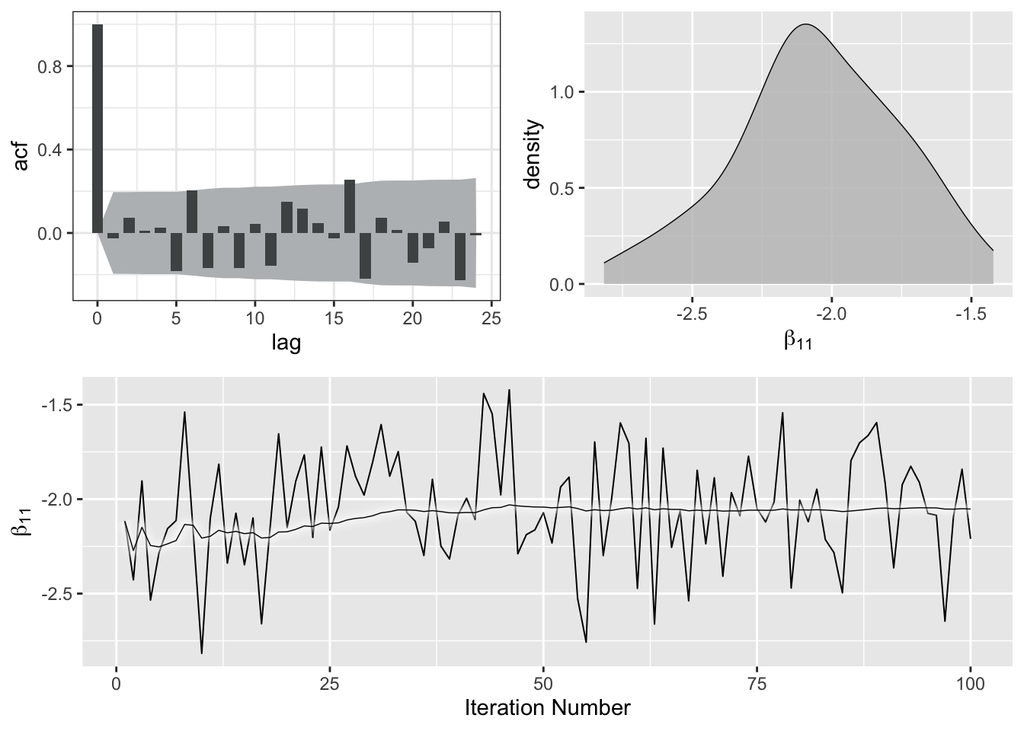

```r
# Summary from MCMC output
i=1;j= 1
  Plot_MCMC_Diag_Triplet(lst$MC$Mc_Beta[,i,j],y_lab_text = bquote(beta[.(i)][.(j)]))
```

```r
  Posterior_Mean=apply(lst$MC$Mc_Beta, MARGIN = c(2,3), FUN = mean)
  Posterior_SD=apply( lst$MC$Mc_Beta, MARGIN = c(2,3), FUN = sd)
  print(cbind(Estimated_Value=c(t(Posterior_Mean)),TrueValue=c(t(data_lst$beta))))
```

```
##        Estimated_Value  TrueValue
##   [1,]      -2.0523795 -2.1001710
##   [2,]      -7.0986596 -7.0225946
##   [3,]       3.4961972  3.8391499
##   [4,]       2.9654886  2.2652010
##   [5,]      10.1280907  9.6643689
##   [6,]      -7.7494592 -7.2189338
##   [7,]      -0.6733766 -0.9680102
##   [8,]       6.2674593  6.0602264
##   [9,]       6.9483670  6.6819024
##  [10,]      -9.4653718 -9.4674591
##  [11,]     -10.1864335 -9.9683085
##  [12,]       5.3587223  5.3822494
##  [13,]      -2.4874465 -2.9858185
##  [14,]      -2.0743759 -2.3416981
```

[output cut: 86 more lines]